# 1.5 非线性方程（组）求解与优化问题

## 1.5.1-3 非线性方程组求根

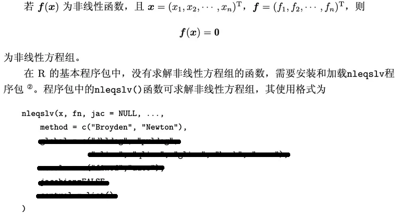

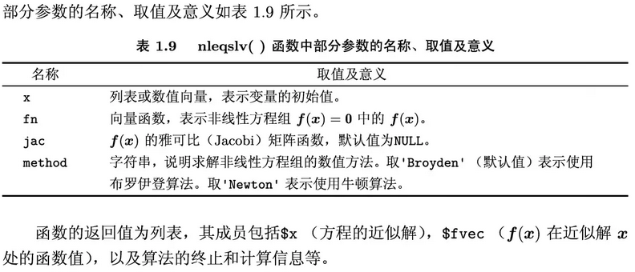

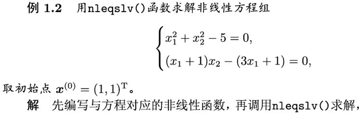

```r
library(nleqslv)

funs <- function (x) {
  y1 <- x[1] ^ 2 + x[2] ^ 2 - 5
  y2 <- (x[1] + 1) * x[2] - (3 * x[1] + 1)
  c(y1, y2)
}

nleqslv(x = c(1, 1), fn = funs)
```

```
## $x
## [1] 1 2
##
## $fvec
## [1]  8.387957e-12 -1.113509e-11
##
## $termcd
## [1] 1
##
## $message
## [1] "Function criterion near zero"
##
## $scalex
## [1] 1 1
##
## $nfcnt
## [1] 9
##
## $njcnt
## [1] 1
##
## $iter
## [1] 9
```

我们也可以推导出雅克比矩阵，写成一个函数提供给`nleqslv`函数使用。

```r
jac.funs <- function (x) {
  dy1.dx1 <- 2 * x[1]
  dy1.dx2 <- 2 * x[2]
  dy2.dx1 <- x[2] - 3
  dy2.dx2 <- x[1] + 1
  matrix(c(dy1.dx1, dy2.dx1, dy1.dx2, dy2.dx2), nrow = 2)
}

nleqslv(x = c(1, 1), fn = funs, jac = jac.funs)
```

[output not shown]

# 1.5.2 优化问题求解

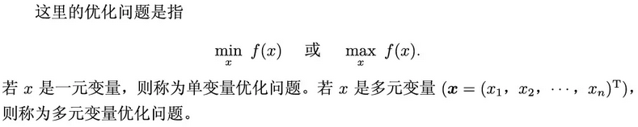

## 1.5.2-1 单变量优化问题

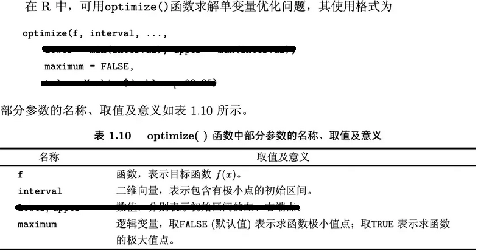

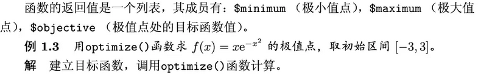

```r
f <- function(x) x * exp(-x ^ 2)

optimize(f, interval = c(-3, 3))
```

```
## $minimum
## [1] -0.7071112
##
## $objective
## [1] -0.4288819
```

```r
optimize(f, interval = c(-3, 3), maximum = TRUE)
```

```
## $maximum
## [1] 0.7071112
##
## $objective
## [1] 0.4288819
```

对于一元函数，作图依然有助于指导给出初始区间。

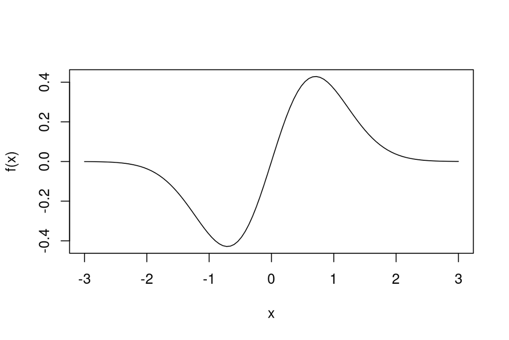

```r
curve(f, from = -3, to = 3)
```

## 1.5.2-2 多变量优化问题

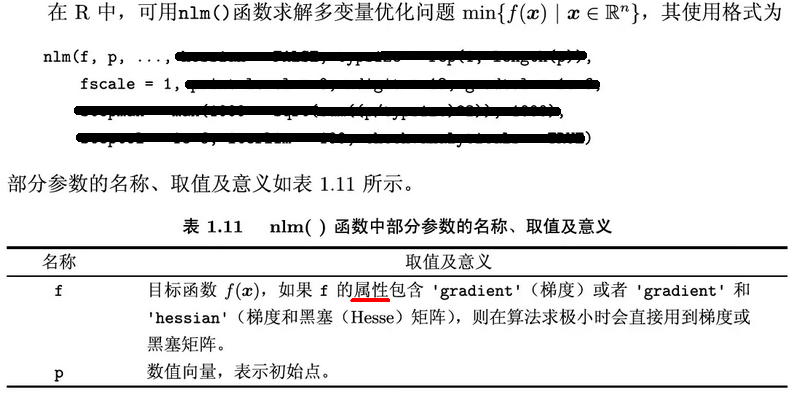

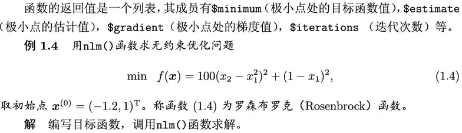

```r
obj0 <- function (x) 100 * (x[2] - x[1] ^ 2) ^ 2 + (1 - x[1]) ^ 2

nlm(obj0, c(-1.2, 1))
```

```
## $minimum
## [1] 3.973765e-12
##
## $estimate
## [1] 0.999998 0.999996
##
## $gradient
## [1] -6.539229e-07  3.335974e-07
##
## $code
## [1] 1
##
## $iterations
## [1] 23
```

可以添加”gradient”属性。

```r
obj1 <- function (x) {
  ## 函数值
  y <- 100 * (x[2] - x[1] ^ 2) ^ 2 + (1 - x[1]) ^ 2
  ## 梯度
  dy.dx1 <- -400 * (x[2] - x[1] ^ 2) * x[1] - 2 * (1 - x[1])
  dy.dx2 <- 200 * (x[2] - x[1] ^ 2)
  grad <- c(dy.dx1, dy.dx2)
  attr(y, "gradient") <- grad
  ## 返回结果
  y
}

nlm(obj1, c(-1.2, 1))
```

```
## $minimum
## [1] 1.182096e-20
##
## $estimate
## [1] 1 1
##
## $gradient
## [1]  2.583521e-09 -1.201128e-09
##
## $code
## [1] 1
##
## $iterations
## [1] 24
```

可进一步添加”hessian”属性。

```r
obj2 <- function (x) {
  ## 函数值
  y <- 100 * (x[2] - x[1] ^ 2) ^ 2 + (1 - x[1]) ^ 2
  ## 梯度
  dy.dx1 <- -400 * (x[2] - x[1] ^ 2) * x[1] - 2 * (1 - x[1])
  dy.dx2 <- 200 * (x[2] - x[1] ^ 2)
  grad <- c(dy.dx1, dy.dx2)
  attr(y, "gradient") <- grad
  ## 黑塞矩阵
  ddy.ddx1 <- 1200 * x[1] ^ 2 - 400 * x[2] + 2
  ddy.ddx2 <- 200
  ddy.dx1dx2 <- -400 * x[1]
  hess <- matrix(c(ddy.ddx1, ddy.dx1dx2, ddy.dx1dx2, ddy.ddx2), 2)
  attr(y, "hessian") <- hess
  ## 返回结果
  y
}

nlm(obj2, c(-1.2, 1))
```

```
## $minimum
## [1] 1.127026e-17
##
## $estimate
## [1] 1 1
##
## $gradient
## [1]  1.297788e-07 -6.560392e-08
##
## $code
## [1] 1
##
## $iterations
## [1] 24
```

Rosenbrock函数又称“香蕉函数”。这里给大家展示一下它的形态。

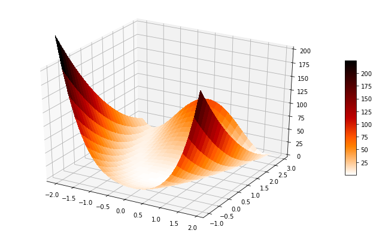

# 作业

1. [不提交] 在上机课上运行本课所有代码；
2. [提交] 课本56页，第18、19、20、21题。